# PAC2

Març 2025

## 🌟 Introducció

Per a realitzar aquesta presentació he utilitzat **RStudio** amb l’eina de **RMarkdown** per a generar una presentació en **HTML (ioslides)**.

Aquesta presentació conté una explicació i exemples de diferents tècniques de visualització de dades:

- 🔥 **Heatmap**
- 📊 **Radar Charts**
- 📈 **Ridgeline Charts**

El codi i els recursos es poden trobar en el següent repositori de GitHub:  
🔗 [PAC2_Visualització_de_Dades](https://github.com/aparareda/PAC2_Visualitzaci-_de_Dades)

## 🌟 Requisits previs

Abans d’executar la presentació, m’asseguro de tenir instal·lades les llibreries necessàries per a R:

```
## -  ggplot2
## -  reshape2
## -  readr
## -  ggridges
## -  tibble
## -  dplyr
## -  fmsb
```

## 📜 Bibliografia

Per a conèixer i veure exemples de les gràfiques i el codi per a realitzar-les he utilitzat les següents webs:

- Data to Viz: https://www.data-to-viz.com
- DataViz Project: https://datavizproject.com
- Catàleg de Visualització de Dades: https://datavizcatalogue.com/ES

## 🔥 Heatmap

- Representació de dades en una **matriu** mitjançant variacions de **color**.
- Útil per identificar **patrons, correlacions i relacions** entre variables.
- Proporciona una **visió general** de les dades numèriques.

**📜 Origen i Autoria**

- El terme *Heat map* va ser introduït per **Cormac Kinney (1991)** per visualitzar dades financeres en temps real.
- Visualitzacions similars ja existien **fa més d’un segle**.

## 🏗️ Estructura d’un Heatmap

- **Files:** Representen una categoria (etiquetes a l’esquerra o dreta).
- **Columnes:** Representen una altra categoria (etiquetes a la part superior o inferior).
- **Celdes:** Contenen dades codificades per color:
  - **Dades categòriques:** Colors fixes.
  - **Dades numèriques:** Escala de colors.

**🎨 Importància de la Llegenda**

- Els *Heatmaps* requereixen **una llegenda** per interpretar-los correctament.
- Escales de color:
  - **Colors sòlids:** Intervals (0-10, 11-20, etc.).
  - **Escales en gradient:** Valors continus (ex: de 0 a 100).

**💡 Funcions Principals**

- **Comparacions:** Permeten analitzar múltiples variables.
- **Dades al llarg del temps:** Per detectar tendències temporals.
- **Patrons:** Identificació de tendències visuals.
- **Relacions:** Anàlisi de correlacions entre variables.

## Avantatges i inconvenients del Heatmap

**✅ Avantatges**

- Visió clara i ràpida de **grans volums de dades**.
- Identificació de **tendències i correlacions**.

**⚠️ Inconvenients**

- Difícil extreure **valors específics**.
- Els colors poden dificultar la interpretació precisa.
- Problemes per a persones amb daltonisme.
- Cal **normalitzar les dades** abans de visualitzar-les.

## 🔍 Bones Pràctiques del Heatmap

- Usar **anàlisi de clústers** per agrupar valors similars.
- Triar **paletes de colors adequades** per millorar la interpretació.
- Afegir **dades en brut** dins les cel·les si cal una lectura precisa.

**📊 Exemples d’Aplicació**

- 🌡️ **Temperatures:** Comparació de temperatures en diferents ciutats durant l’any.
- 📈 **Finances:** Visualització de volums de compra i venda en mercats financers.
- 🖥️ **Màrqueting web:** Mapes de calor per veure on els usuaris fan més clic.
- 🏥 **Medicina:** Expressió gènica en estudis biomèdics.

## 🔥 Heatmap: dades per a realitzar un exemple

- **Font:** [Generalitat de Catalunya](https://administraciodigital.gencat.cat/ca/dades/dades-obertes/informacio-practica/llicencies/)
- **Departament:** Salut
- **Nom del conjunt de dades:** Registre de casos de COVID-19 a Catalunya per municipi i sexe
- **Última actualització:** 19 de febrer de 2025
- **Àmbit geogràfic:** Catalunya
- **Categoria:** Salut
- **Etiquetes:** COVID-19, coronavirus, SARS-CoV-2, ODS3 (Salut i Benestar)

📊 **Accés a les dades:**  
[Registre de casos de COVID-19](https://analisi.transparenciacatalunya.cat/Salut/Registre-de-casos-de-COVID-19-a-Catalunya-per-muni/jj6z-iyrp/about_data)

## 🔥 Heatmap: dades per a realitzar un exemple

- **Descripció:**
  - Recull dades sobre **casos positius** per COVID-19 a Catalunya segons municipi, sexe i tipus de prova.
  - Les dades inclouen **PCR, TAR, ELISA i test ràpid** fins al **26 de juliol de 2022**.
  - Els casos es basen en la **data d’inici de símptomes** i no en la data de la prova.
  - **No es consideren casos positius** els serològics posteriors a la vacunació.
  - **Dades estàtiques** (no s’actualitzen).

📊 **Accés a les dades:**  
[Registre de casos de COVID-19](https://analisi.transparenciacatalunya.cat/Salut/Registre-de-casos-de-COVID-19-a-Catalunya-per-muni/jj6z-iyrp/about_data)

## 🔥 Heatmap: gràfic d’exemple

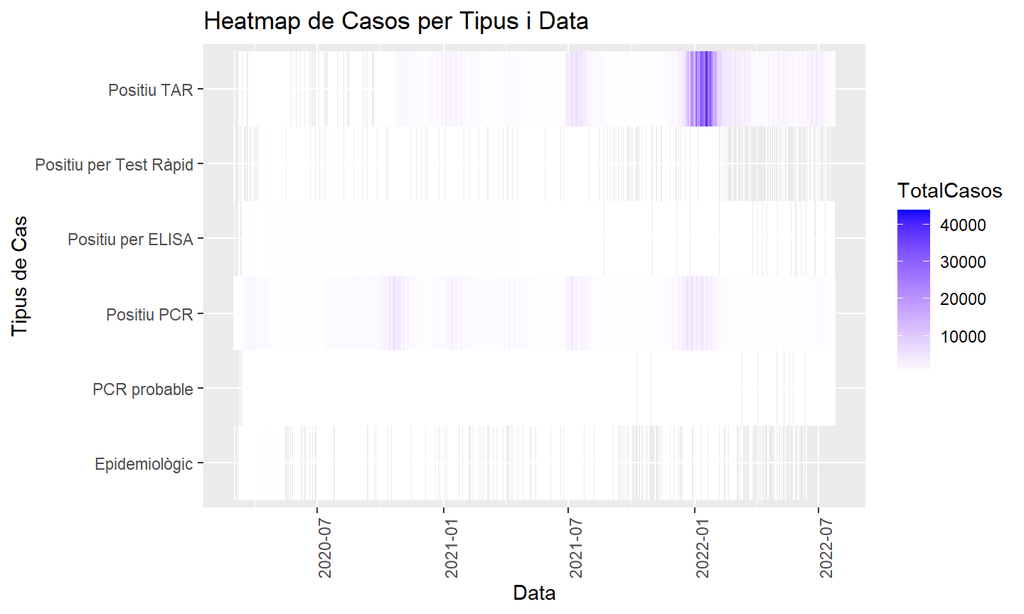

## 🔥 Heatmap: conclusions del gràfic d’exemple

El heatmap mostra la distribució temporal dels casos de COVID-19 a Catalunya segons el tipus de test utilitzat:

1. **Intensitat i pics de casos**:
   - Alta incidència de casos amb pics a finals de 2021 i principis de 2022, especialment per **TAR** i **PCR**.
2. **Evolució en el temps**:
   - Menor intensitat als primers mesos. L’ús de **TAR** creix respecte a la **PCR** a mesura que passa el temps.
3. **Distribució segons tipus de test**:
   - **PCR** i **TAR** són els més utilitzats, mentre que altres mètodes com **ELISA** tenen menor presència.

## 🌟 Radar Chart

- També conegut com: **Web Chart, Spider Chart, Star Chart, Star Plot, Cobweb Chart, Gràfic de Red, Gràfic Polar i Gràfic de Estrella**.
- Representa dades **multivariants** en un gràfic bidimensional.
- Cada variable té el seu propi **eix**, i tots parteixen des del mateix punt central.

## 📜 Com Funciona el Radar Chart?

- Els gràfics radials són útils per **comparar múltiples variables quantitatives**.
- Permeten veure quines variables tenen **valors similars** o si hi ha **valors atípics**.
- Mostren clarament **què variables són altes o baixes** dins d’un conjunt de dades.
- Cada variable té un **eix propi**, tots disposats radialment i amb **la mateixa escala**.
- Les línies de quadrícula serveixen com a guia per ajudar a la interpretació.
- Els valors es tracen al llarg del seu **eix individual** i es connecten per formar un **polígon**.

## ⚠️ Problemes i Limitacions dels Radar Charts

- **Massa polígons** fan el gràfic difícil de llegir i desordenat.
- Si els polígons estan plens, poden **tapar informació rellevant**.
- **Massa variables** creen **massa eixos**, dificultant la interpretació.
- No són ideals per **comparar valors específics** en cada variable.
- La interpretació és menys intuïtiva que en altres gràfics més simples.

## ⚠️ Errors Comuns i Bones Pràctiques* dels Radar Charts

**🚨 Errors Comuns**

- **No incloure més de 5 grups en el mateix gràfic** → Millor utilitzar facetes.
- **Evitar escales diferents entre variables** → Si es fan servir, mostrar clarament les escales.

**✅ Bones Pràctiques**

- Útil per comparar **dades multidimensionals**.
- Més efectiu amb un **nombre reduït de categories**.
- Pot ser útil si es destaquen **patrons generals** en lloc de valors concrets.

## 📊 Exemples d’Aplicació dels Radar Charts

- 🏅 **Comparació de rendiment d’esportistes** en diferents categories.
- 📈 **Avaluació d’indicadors de rendiment** en empreses.
- 🥘 **Anàlisi nutricional** de diferents aliments.

**🔍 Funcions Principals**

- **Comparacions** entre múltiples variables.
- **Relacions** entre els diferents paràmetres.
- **Patrons** que ajuden a identificar tendències.

## 🌟 Radar Charts: dades per a realitzar un exemple

- **Font:** [Generalitat de Catalunya](https://administraciodigital.gencat.cat/ca/dades/dades-obertes/informacio-practica/llicencies/)
- **Departament:** Territori, Habitatge i Transició Ecològica
- **Nom del conjunt de dades:** Estadístiques de residus municipals
- **Última actualització:** 20 de febrer de 2025
- **Àmbit geogràfic:** Catalunya
- **Categoria:** Medi Ambient
- **Etiquetes:** Residus, recollida selectiva, vidre, orgànica, paper, fracció resta, ODS

📊 **Accés a les dades:**  
[Estadístiques de residus municipals](https://analisi.transparenciacatalunya.cat/Medi-Ambient/Estad-stiques-de-residus-municipals/69zu-w48s/about_data)

## 🌟 Radar Charts: dades per a realitzar un exemple

- **Descripció:**
  - Recull estadístiques de residus municipals a Catalunya.
  - Inclou quantitats de recollida selectiva per fraccions, totals en termes absoluts i per càpita.
  - Conté dades sobre la fracció resta i el seu destí.

📊 **Accés a les dades:**  
[Estadístiques de residus municipals](https://analisi.transparenciacatalunya.cat/Medi-Ambient/Estad-stiques-de-residus-municipals/69zu-w48s/about_data)

## 🌟 Radar Charts: gràfic d’exemple

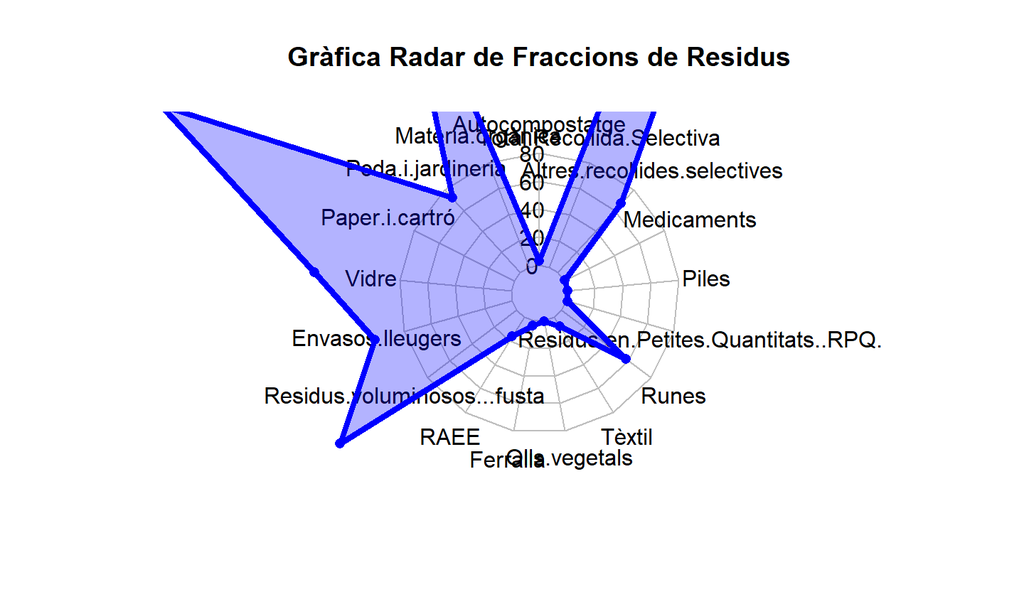

## 🌟 Radar Charts: conclusions del gràfic d’exemple

Aquesta gràfica de radar mostra la distribució de diferents fraccions de residus recollits selectivament:

## 🌄 Ridgeline Charts: Definició

- També coneguts com: **Joyplot**.
- Mostren la **distribució** d’un valor numèric per a diferents grups.
- La distribució es representa amb **histogrames** o **gràfics de densitat**.
- Tots els gràfics es **solapen lleugerament** en un mateix eix horitzontal.

**📜 Com Funciona?**

- Es col·loquen diverses distribucions **alineades** en un mateix eix.
- S’utilitza una **superposició parcial** per optimitzar l’espai.
- Especialment útil quan hi ha **molts grups** a representar.

## 🎯 Quan Utilitzar un Ridgeline Chart?

- Quan cal **visualitzar moltes distribucions** sense ocupar massa espai.
- Quan hi ha **patrons clars** que es poden observar en les dades.
- Quan es vol destacar l’evolució d’una distribució al llarg del temps.

**⚠️ Problemes i Limitacions**

- **Pot ocultar informació** a causa de la superposició.
- **L’elecció de la mida dels bins o l’ample de banda** és crucial per a una correcta interpretació.
- No sempre és intuïtiu si els **grups són massa similars** o poc diferenciats.

## 📊 Exemples d’Aplicació del Ridgeline Chart

- 🎵 **Anàlisi de la durada de cançons** en diferents dècades.
- 🏆 **Distribució d’estadístiques esportives** en diferents equips.
- 🧪 **Mesures experimentals** en diferents condicions de laboratori.

**🚨 Errors Comuns**

- **No ajustar correctament la mida dels bins o el bandwidth** → Això pot afectar la claredat del gràfic.
- **Ús inadequat de la superposició** → Si no hi ha un patró clar, pot dificultar la lectura.

## 🌄 Ridgeline Charts: dades per a realitzar un exemple

- **Font:** [Generalitat de Catalunya](https://administraciodigital.gencat.cat/ca/dades/dades-obertes/informacio-practica/llicencies/)
- **Departament:** Economia i Hisenda
- **Nom del conjunt de dades:** Retribucions del personal funcionari
- **Última actualització:** 19 de febrer de 2025
- **Àmbit geogràfic:** Catalunya
- **Categoria:** Sector Públic
- **Etiquetes:** Retribucions, funcionaris, ODS16 (institucions sòlides), ODS5 (igualtat de gènere)

📊 **Accés a les dades:**  
[Retribucions del personal funcionari](https://analisi.transparenciacatalunya.cat/Sector-P-blic/Retribucions-del-personal-funcionari/b4zx-cfga/about_data)

## 🌄 Ridgeline Charts: dades per a realitzar un exemple

- **Descripció:**
  - Canvis en les retribucions del personal funcionari des de **2007 fins a l’actualitat**.
  - Inclou grup, nivell, sou base, complements, sou total mensual i anual, i imports de triennis.
  - **Actualització anual.**

📊 **Accés a les dades:**  
[Retribucions del personal funcionari](https://analisi.transparenciacatalunya.cat/Sector-P-blic/Retribucions-del-personal-funcionari/b4zx-cfga/about_data)

## 🌄 Ridgeline Charts: gràfic d’exemple

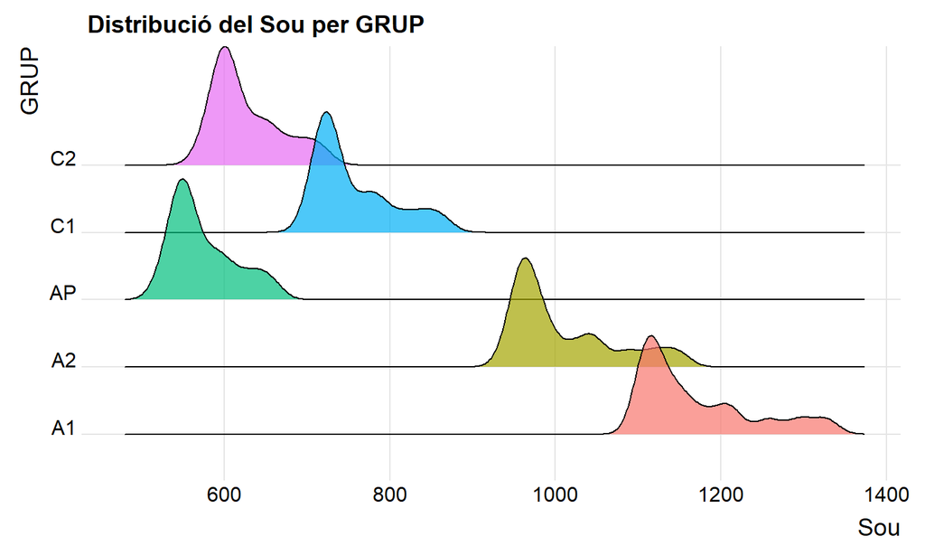

## 🌄 Ridgeline Charts: conclusions del gràfic d’exemple

Aquesta gràfica mostra la distribució del sou per diferents grups (C2, C1, AP, A2 i A1):